# Multiple regression of microbiome and IBD-related variables using HMP datasets

David Xin Zhao

Last edited 24 November 2022

This project was built with R 4.2.1.

```r
# libraries loaded
# if(!requireNamespace("BiocManager", quietly = TRUE))
#     install.packages("BiocManager")
# BiocManager::install("Maaslin2")

library(Maaslin2) # implement multivariate regression
library(tidyverse)
library(knitr)
library(janitor) # create descripitive stats table
library(rmarkdown) # create paged tables
library(ggrepel) # organize labels nicely
library(ggplot2)
library(bslib) # bootswatch themes

# use the function below to list available html output themes
# bslib::bootswatch_themes()
# ?bs_theme to see more variables adjustable in html themes
```

# 1 Data preprocessing

## 1.1 Raw datasets

Set the folder location for the microbiome abundance data set

```r
input_data <- system.file("extdata",
                          "HMP2_taxonomy.tsv",
                          package="Maaslin2") # the abundance table file
```

Set the folder location for the meta data set

```r
input_metadata <- system.file("extdata",
                              "HMP2_metadata.tsv",
                              package = "Maaslin2")  # the metadata table file
```

Read in the microbiome abundance data

```r
df_input_data <- read.table(file = input_data,
                            header = TRUE,
                            sep = "\t",
                            row.names = 1,
                            stringsAsFactors = FALSE)

head(df_input_data, 5) # view first rows
```

|  | Bifidobacterium.adolescentis | Bifidobacterium.bifidum | Bifidobacterium.longum | Bifidobacterium.pseudocatenulatum | Collinsella.aerofaciens | Bacteroides.caccae | Bacteroides.cellulosilyticus | Bacteroides.dorei | Bacteroides.eggerthii | Bacteroides.faecis | Bacteroides.finegoldii | Bacteroides.fragilis | Bacteroides.intestinalis | Bacteroides.massiliensis | Bacteroides.ovatus | Bacteroides.salyersiae | Bacteroides.stercoris | Bacteroides.thetaiotaomicron | Bacteroides.uniformis | Bacteroides.vulgatus | Bacteroides.xylanisolvens | Bacteroidales.bacterium.ph8 | Barnesiella.intestinihominis | Coprobacter.fastidiosus | Odoribacter.splanchnicus | Parabacteroides.distasonis | Parabacteroides.goldsteinii | Parabacteroides.merdae | Parabacteroides.unclassified | … |
| --- | --- | --- | --- | --- | --- | --- | --- | --- | --- | --- | --- | --- | --- | --- | --- | --- | --- | --- | --- | --- | --- | --- | --- | --- | --- | --- | --- | --- | --- | --- |
| CSM5FZ4M | 0.0000000 | 0 | 0.0000000 | 0 | 0.0000000 | 0.0000299 | 0.0000000 | 0.1306320 | 0 | 0.0000000 | 0 | 0.0000000 | 0 | 0.00e+00 | 0.1908630 | 0.0090411 | 0.0000000 | 0.0199315 | 0.3258120 | 0.0000362 | 0.0111190 | 0.0000000 | 0.0000000 | 0.0000000 | 0.0000000 | 0.0026035 | 0 | 0.0000000 | 0.0605912 | … |
| CSM5MCUO | 0.0002803 | 0 | 0.0002857 | 0 | 0.0002506 | 0.0257430 | 0.0003977 | 0.0057939 | 0 | 0.0025964 | 0 | 0.0062334 | 0 | 0.00e+00 | 0.0344354 | 0.0129821 | 0.0836427 | 0.0006236 | 0.0677076 | 0.1691570 | 0.0009044 | 0.0024183 | 0.0195324 | 0.0000000 | 0.0030421 | 0.0000000 | 0 | 0.0026058 | 0.0000000 | … |
| CSM5MCVL | 0.0000000 | 0 | 0.0000000 | 0 | 0.0006440 | 0.0000000 | 0.0000000 | 0.0000304 | 0 | 0.0000000 | 0 | 0.2603660 | 0 | 0.00e+00 | 0.0000246 | 0.0000000 | 0.0000000 | 0.1293830 | 0.0000000 | 0.3140030 | 0.0232747 | 0.0000000 | 0.0000000 | 0.0000000 | 0.0000000 | 0.0000000 | 0 | 0.0000000 | 0.0001241 | … |
| CSM5MCVN | 0.0000000 | 0 | 0.0000000 | 0 | 0.0000079 | 0.0000000 | 0.0000000 | 0.0000062 | 0 | 0.0000000 | 0 | 0.1490410 | 0 | 1.25e-05 | 0.0000000 | 0.0000000 | 0.0000000 | 0.0832982 | 0.0000000 | 0.4237980 | 0.0164535 | 0.0000000 | 0.0000000 | 0.0000000 | 0.0000000 | 0.0000000 | 0 | 0.0000000 | 0.0006701 | … |
| CSM5MCW6 | 0.0000000 | 0 | 0.0000000 | 0 | 0.0000000 | 0.0000000 | 0.0000000 | 0.7979280 | 0 | 0.0000000 | 0 | 0.0000000 | 0 | 0.00e+00 | 0.0000000 | 0.0000000 | 0.0000000 | 0.0000000 | 0.0000000 | 0.0000000 | 0.0000000 | 0.0000000 | 0.0000000 | 0.0033702 | 0.0204998 | 0.0000000 | 0 | 0.0000000 | 0.0000000 | … |

Read in the metadata

```r
df_input_metadata <- read.table(file=input_metadata,
                                header = T,
                                sep="\t",
                                row.names = 1,
                                stringsAsFactors = F)

head(df_input_metadata, 5) # view first rows
```

|  | site | age | diagnosis | subject | antibiotics | dysbiosis_binary | dysbiosis | dysbiosisnonIBD | dysbiosisUC | dysbiosisCD | collection |
| --- | --- | --- | --- | --- | --- | --- | --- | --- | --- | --- | --- |
| CSM5FZ3N_P | Cedars-Sinai | 43 | CD | C3001 | No | No | 0.7923148 | No | No | No | 1 |
| CSM5FZ3R_P | Cedars-Sinai | 43 | CD | C3001 | No | No | 0.8379234 | No | No | No | 2 |
| CSM5FZ3T_P | Cedars-Sinai | 76 | CD | C3002 | No | Yes | 0.9242969 | No | No | Yes | 1 |
| CSM5FZ3V_P | Cedars-Sinai | 43 | CD | C3001 | No | No | 0.8304005 | No | No | No | 4 |
| CSM5FZ3X_P | Cedars-Sinai | 76 | CD | C3002 | No | Yes | 0.9109670 | No | No | Yes | 2 |

## 1.2 Exploratory data analysis

Generate descriptive statistics for microbiome relative abundance data, calculating mean, standard deviations and rate of missing values

```r
# descriptive stats for top 20 abundant genus
df_input_data_long <- df_input_data %>%
  rownames_to_column("sample") %>%
  gather(key="genus", value="rel_abund", -sample) #reshape short to long data frame

summary_genus <- df_input_data_long %>%
  group_by(genus) %>%
  summarise(average = mean(rel_abund, na.rm=TRUE)*100,
            std = sd(rel_abund, na.rm=TRUE)*100,
            zero_rate = mean(rel_abund == 0)*100)%>%
  arrange(desc(average)) %>%
  head(20)  # top 20 genus based on average relative abundance


# display summary of relative abundance at genus level in a table
kable(summary_genus,
      col.names = c("Species",
                    "Average percentage",
                    "Standard deviation",
                    "Zeroness percentage"),
      caption = 'Descriptive statistics of top 20 abundant species',
      format = 'html',
      digits = 2)
```

Descriptive statistics of top 20 abundant species

| Species | Average percentage | Standard deviation | Zeroness percentage |
| --- | --- | --- | --- |
| Faecalibacterium.prausnitzii | 10.86 | 11.38 | 3.82 |
| Bacteroides.uniformis | 7.63 | 10.25 | 12.79 |
| Bacteroides.vulgatus | 6.85 | 9.98 | 8.78 |
| Bacteroides.stercoris | 5.99 | 10.79 | 33.35 |
| Prevotella.copri | 4.71 | 14.99 | 72.48 |
| Eubacterium.rectale | 3.92 | 6.08 | 17.37 |
| Bacteroides.ovatus | 3.66 | 6.24 | 17.30 |
| Alistipes.putredinis | 3.11 | 4.62 | 41.07 |
| Subdoligranulum.unclassified | 3.05 | 4.27 | 3.07 |
| Bacteroides.fragilis | 3.00 | 7.84 | 44.14 |
| Bacteroides.caccae | 2.95 | 4.47 | 32.79 |
| Roseburia.intestinalis | 2.65 | 7.97 | 37.24 |
| Bacteroides.dorei | 2.59 | 8.74 | 34.29 |
| Bacteroides.massiliensis | 1.90 | 5.08 | 63.82 |
| Parabacteroides.merdae | 1.82 | 3.07 | 42.88 |
| Bacteroides.thetaiotaomicron | 1.78 | 4.08 | 29.72 |
| Escherichia.coli | 1.64 | 6.52 | 38.87 |
| Akkermansia.muciniphila | 1.23 | 5.19 | 63.76 |
| Bacteroides.eggerthii | 1.14 | 4.86 | 80.63 |
| Parabacteroides.distasonis | 1.12 | 3.40 | 41.38 |

```r
# inspect metadata

df_input_metadata # print paged table
```

|  | site | age | diagnosis | subject | antibiotics | dysbiosis_binary | dysbiosis | dysbiosisnonIBD | dysbiosisUC | dysbiosisCD | collection |
| --- | --- | --- | --- | --- | --- | --- | --- | --- | --- | --- | --- |
| CSM5FZ3N_P | Cedars-Sinai | 43 | CD | C3001 | No | No | 0.7923148 | No | No | No | 1 |
| CSM5FZ3R_P | Cedars-Sinai | 43 | CD | C3001 | No | No | 0.8379234 | No | No | No | 2 |
| CSM5FZ3T_P | Cedars-Sinai | 76 | CD | C3002 | No | Yes | 0.9242969 | No | No | Yes | 1 |
| CSM5FZ3V_P | Cedars-Sinai | 43 | CD | C3001 | No | No | 0.8304005 | No | No | No | 4 |
| CSM5FZ3X_P | Cedars-Sinai | 76 | CD | C3002 | No | Yes | 0.9109670 | No | No | Yes | 2 |
| CSM5FZ3Z_P | Cedars-Sinai | 76 | CD | C3002 | No | Yes | 0.9122817 | No | No | Yes | 3 |
| CSM5FZ42_P | Cedars-Sinai | 76 | CD | C3002 | No | Yes | 0.9030491 | No | No | Yes | 4 |
| CSM5FZ44_P | Cedars-Sinai | 76 | CD | C3002 | No | Yes | 0.8782548 | No | No | Yes | 5 |
| CSM5FZ46_P | Cedars-Sinai | 76 | CD | C3002 | No | Yes | 0.9254287 | No | No | Yes | 6 |
| CSM5FZ4A_P | Cedars-Sinai | 47 | UC | C3004 | No | No | 0.7751605 | No | No | No | 1 |

[output cut: 1585 more lines]

Visualize relationship between representative genus and dysbiosis (continuous variable), stratified by diagnosis status

```r
#extract top 10 genus with highest average of relative abundance
top10_g <- summary_genus %>%
  arrange(desc(average)) %>%
  head(10) %>%
  pull(genus)

#select top 10 representative genus
df_input_data_top <- df_input_data %>%
  select(all_of(top10_g)) %>%
  rownames_to_column("subject_id")

#subset dysbiosis and diagnosis variables
df_input_metadata_sub <- df_input_metadata %>%
  select(diagnosis, dysbiosis) %>%
  rownames_to_column("subject_id")

#merge microbiome data and metadata
merge_micro_meta_top <- df_input_data_top %>%
  inner_join(df_input_metadata_sub, by="subject_id")
```

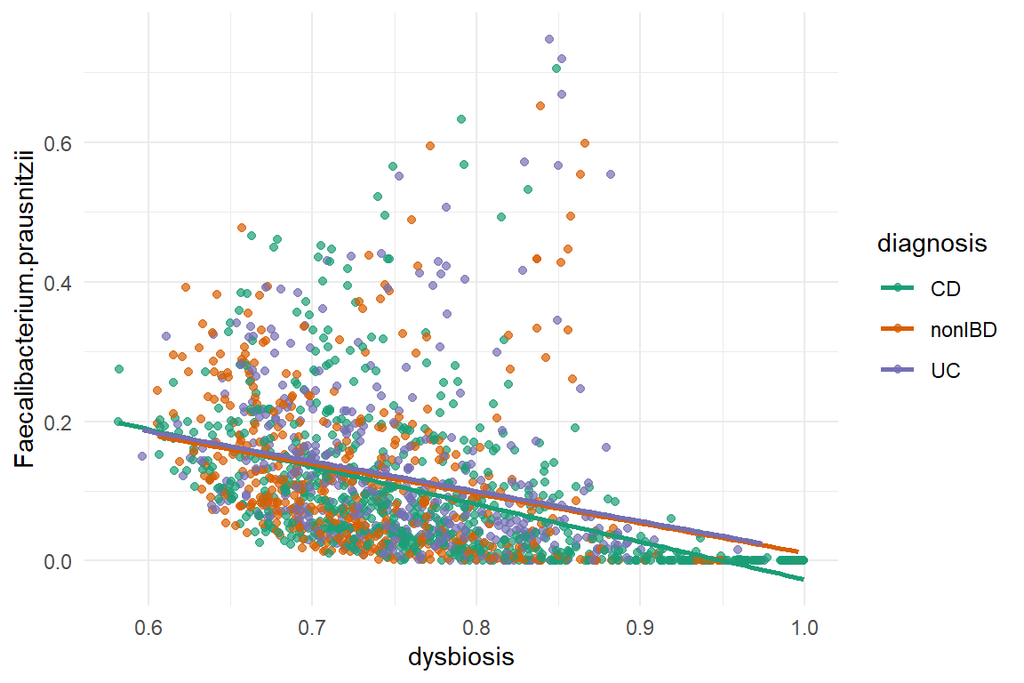

Relationship between representative top genus and diagnosis

```r
# scatter plot given genus vs dysbiosis with faceting by diagnosis status (for instance, F. prausnitzii)
require(RColorBrewer)

ggplot(merge_micro_meta_top, aes(x= dysbiosis,
                                 y=Faecalibacterium.prausnitzii,
                                 color=diagnosis))+
  geom_point(alpha=0.7)+
  geom_smooth(method = "lm",
              se=FALSE)+
  scale_color_brewer(palette = "Dark2")+
  theme_minimal()
```

There were 11 covariates in mete-data as follows, `age`, `dysbiosis`, and `collection` were numerical variables; and `site`, `diagnosis`, `subject`, `antibiotics`, `dysbiosis_binary`, `dysbiosisnonIBD`, `dysbiosisUC`, `dysbiosisCD` were character variables.

In addition, missing values were present in three variables, `dysbiosisnonIBD`, `dysbiosisUC`, `dysbosisCD`.

```r
# convert some character variables to factor variables
# diagnosis
df_input_metadata$diagnosis <- factor(df_input_metadata$diagnosis,
                                      levels = c("nonIBD", # set "nonIBD" a reference level
                                                 "UC",
                                                 "CD"))

# convert remaining character variables to binary factor variables
df_input_metadata <- df_input_metadata %>%
  mutate(site = factor(site),
         antibiotics = factor(antibiotics),
         dysbiosis_binary = factor(dysbiosis_binary),
         dysbiosisnonIBD = factor(dysbiosisnonIBD),
         dysbiosisUC = factor(dysbiosisUC),
         dysbiosisCD = factor(dysbiosisCD))

# summary(df_input_metadata) # investigate again the resulting meta-data
```

```r
# site distribution by diagnosis levels
df_site <- tabyl(df_input_metadata, site, diagnosis) %>%
  adorn_totals(c("row", "col"))%>%
  adorn_percentages("row") %>%
  adorn_pct_formatting(digits = 0) %>%
  adorn_ns() %>%  # combine count and percentage
  add_row(site = "site",
          .before = 1) %>%  #add one row showing variable name
  filter(row_number() !=7) #remove total row
```

Follow the instruction in [programming with dyplyr](https://dplyr.tidyverse.org/articles/programming.html)

```r
cat_cov <- df_input_metadata %>%
  select(where(is.factor)) %>%
  select(-diagnosis) %>%
  colnames()

sum_cat <- lapply(cat_cov, count_pct) #list of summary of multiple categorical variables
# combine each element of the list by rows before storing in a data frame
df_sum_cat <- as.data.frame(do.call(rbind, sum_cat))
```

```r
str(df_input_metadata)

numerical_summary <- function(x){
dat_ns <- df_input_metadata %>%
  group_by(diagnosis) %>%
  summarise(average = round(mean(.data[[x]], na.rm=T),2),
            std = round(sd(.data[[x]], na.rm = T),2)) %>%
  select(-average)

df_num_sub <- df_input_metadata %>%
  group_by(diagnosis) %>%
  summarise(average = round(mean(.data[[x]], na.rm=T),2)) %>%
  adorn_ns(ns = dat_ns)%>%
  rename("average (sd)"= average) %>%
  spread(key=diagnosis, value = "average (sd)") %>%
  mutate(covariable = x) %>%
  select(covariable, 1:3)


total_dat_ns <- df_input_metadata %>%
  summarise(average = round(mean(.data[[x]], na.rm=T),2),
            std = round(sd(.data[[x]], na.rm = T),2)) %>%
  select(-average) %>%
  mutate(covariable = x) %>%
  select(covariable, std)

df_num <- df_input_metadata %>%
  summarise(average = round(mean(.data[[x]], na.rm=T),2)) %>%
  mutate(covariable = x) %>%
  select(covariable, average) %>%
  adorn_ns(ns = total_dat_ns) %>%
  rename("average (sd)" = average)

df_num_bind <- cbind(df_num_sub, df_num[,2])

colnames(df_num_bind)[5] <- "overall"

print(df_num_bind)
}

numerical_summary("age") #the resulting function works properly
```

[output not shown]

Apply the function `numerical_summary` to all the numerical variables in meta-data with `lapply`.

```r
# extract column names for all the numerical variables in meta-data
num_names <- df_input_metadata %>%
  select(where(is.numeric)) %>%
  colnames()

list_num_summary <- lapply(num_names, numerical_summary)

# str(list_num_summary)

# convert individual element of the list to data frames and bind them into a single data frame
df_num_summary <- as.data.frame(do.call(rbind, list_num_summary))
```

Combine descriptive stats tables, `df_sum_cat` and `df_num_summary` for categorical and numerical covariables, respectively

```r
# head(df_sum_cat, 3)
# head(df_num_summary, 3)

names(df_sum_cat)[5] <- "overall"  #rename the column name

df_all_cov <- bind_rows(df_sum_cat, df_num_summary) #bind by rows

#replace NA in the column, "co variable" with " unknown"
df_all_cov$covariable <- as.character(df_all_cov$covariable)
df_all_cov$covariable %>% replace_na("unknown")
```

```
##  [1] "site"             "Cedars-Sinai"     "Cincinnati"       "Emory"
##  [5] "MGH"              "MGH Pediatrics"   "antibiotics"      "No"
##  [9] "Yes"              "dysbiosis_binary" "No"               "Yes"
## [13] "dysbiosisnonIBD"  "No"               "Yes"              "unknown"
## [17] "dysbiosisUC"      "No"               "Yes"              "unknown"
## [21] "dysbiosisCD"      "No"               "Yes"              "unknown"
## [25] "age"              "dysbiosis"        "collection"
```

Apply chi-square test and ANOVA to categorical descriptive stats and numerical descriptive stats, respectively

```r
# write a function to do chi-square to categorical variables
chi_square <- function(x){
  chisq <- chisq.test(df_input_metadata[[x]], df_input_metadata$diagnosis)

  pval <- chisq$p.value

  pval_digit <- format(round(pval, 3), nsmall=4)

  print(pval_digit)

}

# chi_square("site")

df_pval_cat <- data.frame(covariable = cat_cov,
                          pvalue = numeric(length = length(cat_cov)))   #create empty df to store p-values

df_pval_cat$pvalue <- sapply(cat_cov, chi_square)
```

```
## [1] "0.0000"
## [1] "0.0000"
## [1] "0.0000"
## [1] "0.0000"
## [1] "0.0000"
## [1] "0.0000"
```

```r
#write a function to do anova to numerical variables against diagnosis
anova_num <- function(x){
  f <- paste0(x, "~", "diagnosis")

  pval <- anova(lm(f, data=df_input_metadata))$"Pr(>F)"[1]

  pval_digit <- format(round(pval, 3), nsmall=5)

  print(pval_digit)
}

df_pval_num <- data.frame(covariable = num_names,
                          pvalue = numeric(length = length(num_names)))   #create empty df to store p-values

df_pval_num$pvalue <- sapply(num_names, anova_num)
```

```
## [1] "0.00000"
## [1] "0.00000"
## [1] "0.61700"
```

```r
#join p-values with descriptive stats table
df_all_cov_pval <- df_all_cov %>%
  left_join(df_pval_num, by="covariable") %>%
  left_join(df_pval_cat, by="covariable")

df_all_cov_pval$pvalue.x <- if_else(!is.na(df_all_cov_pval$pvalue.x),
                            df_all_cov_pval$pvalue.x,
                            df_all_cov_pval$pvalue.y)

df_all_cov_pval$covariable <- if_else(!is.na(df_all_cov_pval$covariable),
                            df_all_cov_pval$covariable,
                            "unknown")

df_all_cov_pval2 <- df_all_cov_pval %>% select(-pvalue.y) %>% rename(pvalue = pvalue.x)

df_all_cov_pval2 #view the resulting table
```

| covariable | nonIBD | UC | CD | overall | pvalue |
| --- | --- | --- | --- | --- | --- |
| site | NA | NA | NA | NA | 0.0000 |
| Cedars-Sinai | 5% (21) | 40% (164) | 55% (222) | 100% (407) | NA |
| Cincinnati | 34% (157) | 20% (94) | 46% (211) | 100% (462) | NA |
| Emory | 8% (5) | 25% (16) | 67% (42) | 100% (63) | NA |
| MGH | 45% (198) | 23% (100) | 33% (146) | 100% (444) | NA |
| MGH Pediatrics | 21% (45) | 29% (63) | 51% (111) | 100% (219) | NA |
| antibiotics | NA | NA | NA | NA | 0.0000 |
| No | 29% (410) | 29% (414) | 43% (613) | 100% (1437) | NA |
| Yes | 10% (16) | 15% (23) | 75% (119) | 100% (158) | NA |
| dysbiosis_binary | NA | NA | NA | NA | 0.0000 |

[output cut: 17 more lines]

# 2 Fit the mdoel

Run MaAsLin2 on the HMP2 data, building a multiple regression model to evaluate the association between microbial species (relative abundance) and `dysbiosis` scores adjusting for IBD `diagnosis` status.

Key arguments were set as followings, - linear regression was used for data modeling `analysis_method` = `LM` - set the minimal threshold for taxa prevalence as 0.1 `min_prevalence` = `0.1` - set the minimal threshold for taxa relative abundance as 0.01% `min_abundance` = `0.0001` - fixed effect variables `fixed_effects` = `c("diagnosis", "dysbiosis")` - random effect variable `random_effects` = `c("subject")`  
- set the baseline for the categorical variable `diagnosis` `reference` = `c("diagnosis","nonIBD")`

Note that MaAsLin2 can not yet handle interaction terms directly in model building. Alternatively, persons can add additional interactive covariables in the input data frame prior to modeling.

```r
fit_data2 <- Maaslin2(
        input_data = df_input_data,
        input_metadata = df_input_metadata,
        min_prevalence = 0.1, #typical prevalence threshold: 10-50% (up to 70-90% can be reasonable)
        min_abundance = 0.0001, #typical relative abundance threshold: 0.0001
        normalization = "NONE",  #without additional normalization
        output = "demo_output2",
        max_significance = 0.1,
        plot_heatmap = FALSE,
        plot_scatter = FALSE,
        analysis_method = "LM",  #linear regression model
        fixed_effects = c("diagnosis", "dysbiosis"), # fixed effect variables, diagnosis and dysbiosis
        random_effects = c("subject"), # random effect variable
        reference = c("diagnosis,nonIBD")) #set the baseline for the categorical variable, diagnosis

all_results <- fit_data2$results #extract coefficients and q-value
```

## 2.1 Significant taxa checkup

significant associations is provided in `significant_results.tsv`

```r
sig_results <- all_results %>%
        filter(qval <= 0.05) %>% #sig threshold q value = 0.05
        arrange(qval)

sig_results  # print in the paged table format
```

| feature | metadata | value | coef | stderr | pval | name | qval | N | N.not.zero |
| --- | --- | --- | --- | --- | --- | --- | --- | --- | --- |
| Faecalibacterium.prausnitzii | dysbiosis | dysbiosis | -2.6011472 | 0.08354458 | 1.817890e-165 | dysbiosis | 4.581083e-163 | 1595 | 1534 |
| Subdoligranulum.unclassified | dysbiosis | dysbiosis | -1.4570705 | 0.07092002 | 3.596769e-83 | dysbiosis | 4.531929e-81 | 1595 | 1546 |
| Bacteroides.uniformis | dysbiosis | dysbiosis | -2.1662652 | 0.11352360 | 2.940839e-73 | dysbiosis | 2.470305e-71 | 1595 | 1391 |
| Eubacterium.rectale | dysbiosis | dysbiosis | -2.4477468 | 0.13298192 | 1.100929e-68 | dysbiosis | 6.935850e-67 | 1595 | 1318 |
| Ruminococcus.obeum | dysbiosis | dysbiosis | -1.5238531 | 0.09744731 | 3.268299e-51 | dysbiosis | 1.647223e-49 | 1595 | 1346 |
| Alistipes.putredinis | dysbiosis | dysbiosis | -2.0041024 | 0.13020836 | 6.495960e-50 | dysbiosis | 2.728303e-48 | 1595 | 940 |
| Bacteroides.vulgatus | dysbiosis | dysbiosis | -1.5428680 | 0.10038171 | 9.090160e-50 | dysbiosis | 3.272458e-48 | 1595 | 1455 |
| Alistipes.shahii | dysbiosis | dysbiosis | -1.5599548 | 0.10353085 | 5.215580e-48 | dysbiosis | 1.642908e-46 | 1595 | 757 |
| Coprococcus.comes | dysbiosis | dysbiosis | -1.3888742 | 0.09977186 | 1.185529e-41 | dysbiosis | 3.319480e-40 | 1595 | 848 |
| Eubacterium.eligens | dysbiosis | dysbiosis | -1.8804274 | 0.13630211 | 5.628795e-41 | dysbiosis | 1.418456e-39 | 1595 | 1015 |

[output cut: 68 more lines]

Draw a volcano plot to illustrate q-values and coefficients

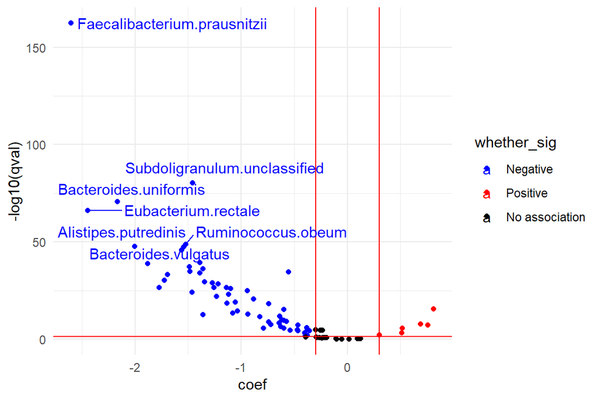

```r
# add a column to indicate significant genus
all_results_sig <- all_results %>%
  mutate(whether_sig = case_when(coef >= 0.3 & qval <= 0.05 ~ "Positive",
                                 coef <= -0.3 & qval <= 0.05 ~ "Negative",
                                 abs(coef) < 0.3 | qval >0.05 ~ "No association"))


# add label column
all_results_sig$relabel <- NA

all_results_sig$relabel[all_results_sig$whether_sig != "No association"] <- all_results_sig$feature[all_results_sig$whether_sig != "No association"]

# set personal color palate
mycolors <- c("blue", "red", "black")
names(mycolors) <- c("Negative", "Positive", "No association")

# volcano plot
all_results_sig %>%
  filter(value == "dysbiosis") %>% #focus on dysbiosis
ggplot(aes(x=coef, y=-log10(qval),
           color=whether_sig,
           label=relabel))+
  geom_point()+
  geom_vline(xintercept = c(-0.3, 0.3), color="red")+
  geom_hline(yintercept = -log10(0.05), color="red")+
  scale_color_manual(values = mycolors)+
  theme_minimal()+
  geom_text_repel() #label taxa names
```

## 2.2 Model interpretation

Use `Faecalibacterium.prausnitzii` as an example for model interpretation.

```r
coef_Fae <- all_results_sig %>%
  filter(value == "dysbiosis") %>%
  filter(feature == "Faecalibacterium.prausnitzii") %>%
  select(coef) %>%
  pull() %>%
  round(., 3)

qval_Fae <- all_results_sig %>%
  filter(value == "dysbiosis") %>%
  filter(feature == "Faecalibacterium.prausnitzii") %>%
  select(qval) %>%
  pull() %>%
  format(., scientific=TRUE)
```

*F. prausnitzii* is negatively associated with `dysbiosis` (q value = 4.581083e-163). In particularly, *F. prausnitzii* percentage in feces may decrease by 2.601 on average when `dysbiosis` scores increases by 1 unit independent of `diagnosis` status.